# Pre-processing of paired-reads

Progress report

Updated: 2018-10-18 03:52:17

# Raw read features

## Original read count

```
Number of forward reads before QC (Original_R1):     3634461 ( 100 % )
```

```
Number of reverse reads before QC (Original_R2):     3634461 ( 100 % )
```

```
Total number of reads before QC:     7268922
```

## Read length

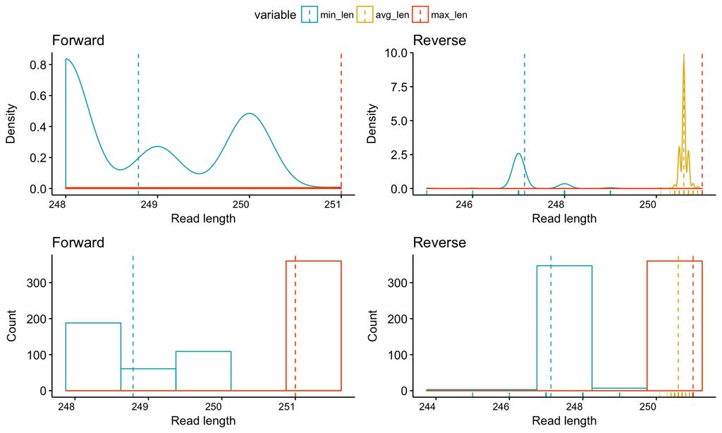

Figure x: ensity and histograms plots showing forward and reverse read length. Dotted line indicates mean value for the specified variable

# Distribution of raw reads

## Barplots

**Grouped by Sex variable**

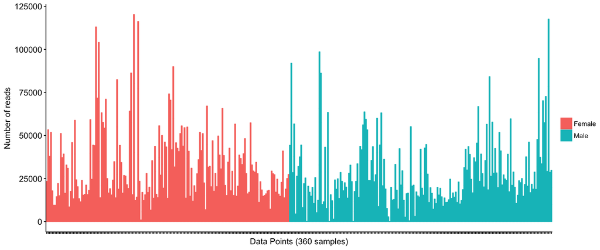

Figure x: Barplots of pre-processed reads grouped by sex variable.

**Grouped by Time variable**

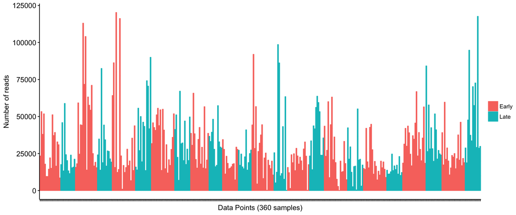

Figure x: Barplots of pre-processed reads grouped by time variable

**Grouped by days-post-weaning (D) variable**

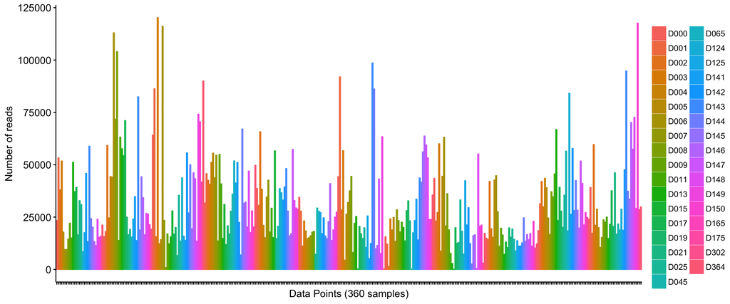

# Base call quality

- In the results folder you will find a folder named *multiqc* which contains data for HTML display. Right-click-open with your favorite browser
- Using CLI: Alternatively, open the HTML file on command line by running the following commands

## Original base call quality (qc0)

```
open ./results/multiqc/qc0/multiqc_report.html
open ./results/multiqc/qc0/R1/multiqc_report.html
open ./results/multiqc/qc0/R2/multiqc_report.html
```

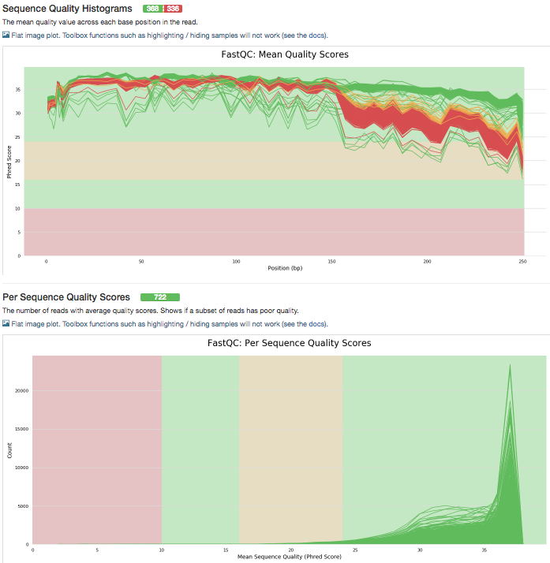

Figure x: Example of report generated by running **open ./results/multiqc/qc0/multiqc_report.html** on CLI

# Trimming & filtering poor reads

## Base call quality after trimming at Q = 25 (qctrim25)

```
open ./results/multiqc/qctrim25/multiqc_report.html
open ./results/multiqc/qctrim25/R1/multiqc_report.html
open ./results/multiqc/qctrim25/R2/multiqc_report.html
```

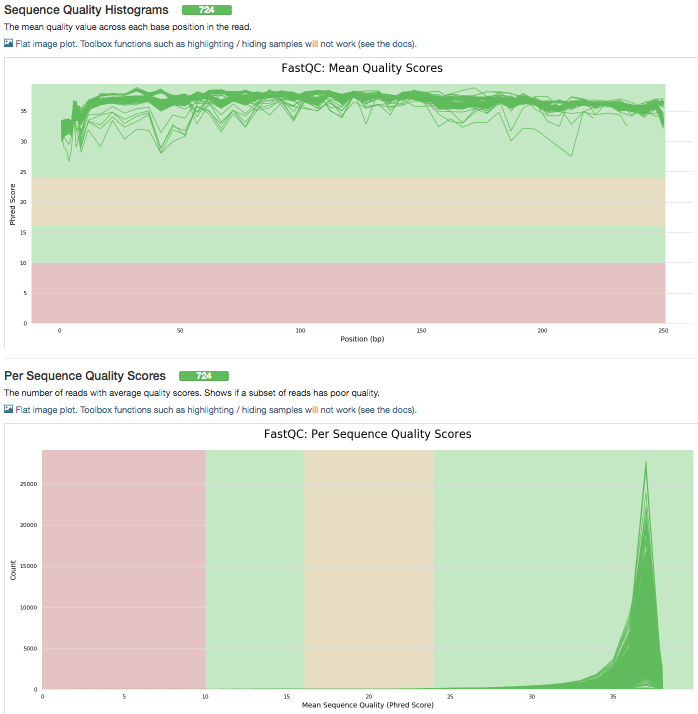

## Base call quality after removing phiX

```
open ./results/multiqc/qced/multiqc_report.html
open ./results/multiqc/qced/R1/multiqc_report.html
open ./results/multiqc/qced/R2/multiqc_report.html
```

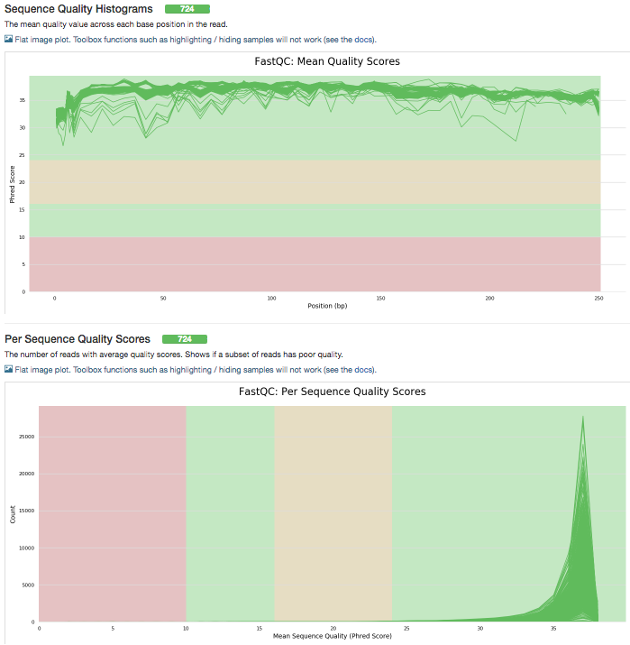

# Status of pre-processed reads

- Check for missing data

| variable | q_zeros | p_zeros | q_na | p_na | q_inf | p_inf | type | unique |
| --- | --- | --- | --- | --- | --- | --- | --- | --- |
| SampleID | 0 | 0 | 0 | 0 | 0 | 0 | character | 360 |
| origGroup | 0 | 0 | 0 | 0 | 0 | 0 | character | 360 |
| Sex | 0 | 0 | 0 | 0 | 0 | 0 | character | 2 |
| Time | 0 | 0 | 0 | 0 | 0 | 0 | character | 2 |
| DayID | 0 | 0 | 0 | 0 | 0 | 0 | character | 35 |
| Original_R1 | 0 | 0 | 0 | 0 | 0 | 0 | numeric | 357 |
| TrimQ25_R1 | 0 | 0 | 0 | 0 | 0 | 0 | numeric | 357 |
| NophiX_R1 | 0 | 0 | 0 | 0 | 0 | 0 | numeric | 359 |
| Original_R2 | 0 | 0 | 0 | 0 | 0 | 0 | numeric | 357 |
| TrimQ25_R2 | 0 | 0 | 0 | 0 | 0 | 0 | numeric | 357 |
| NophiX_R2 | 0 | 0 | 0 | 0 | 0 | 0 | numeric | 359 |

Key: **q_zeros**: quantity of zeros or missing data ; **q_na**: quantity of NA; **q_inf**: quantity of infinite values; **type**: factor, character, integer or numeric..; **unique**: quantity of unique values. Percentages are indicated by **p_**.

# Distribution of pre-processed reads

- Bar plots
- Box plots
- Density plots

## Stacked bar plot

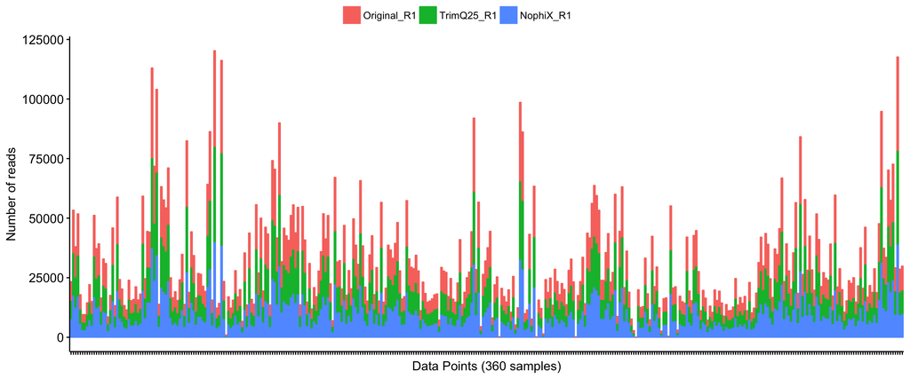

Figure x: Stacked barplots of pre-processed reads grouped by QC variable

## Boxplots

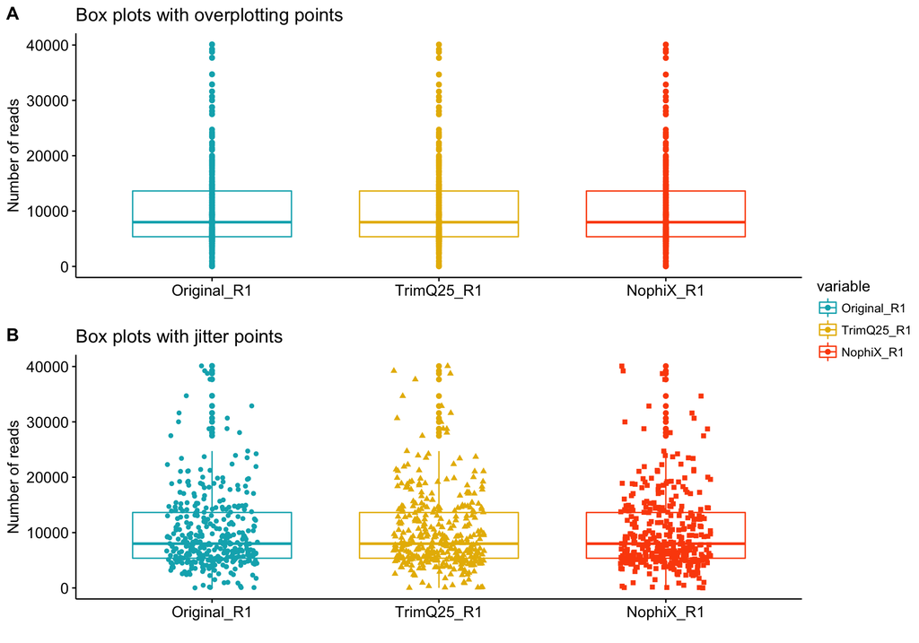

Figure x: Boxplot of pre-processed reads plotted with overplotting points (A) and jitter points (B).

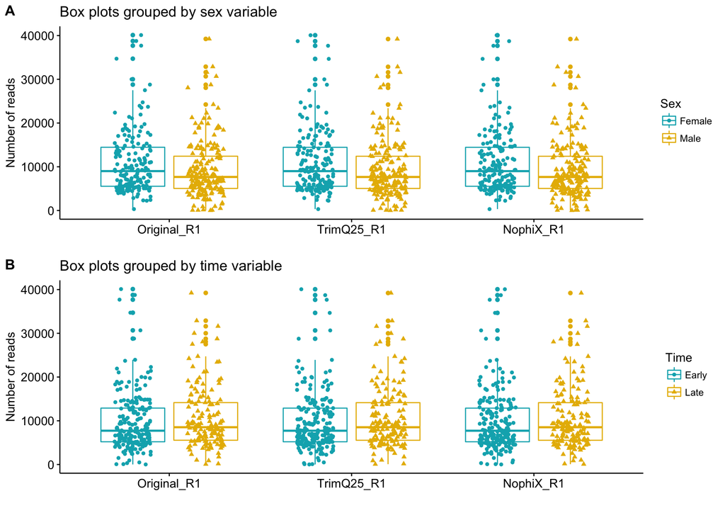

Figure x: Boxplot of pre-processed reads by groups. Sex variable (A) and Time variable (B)

## Density plots

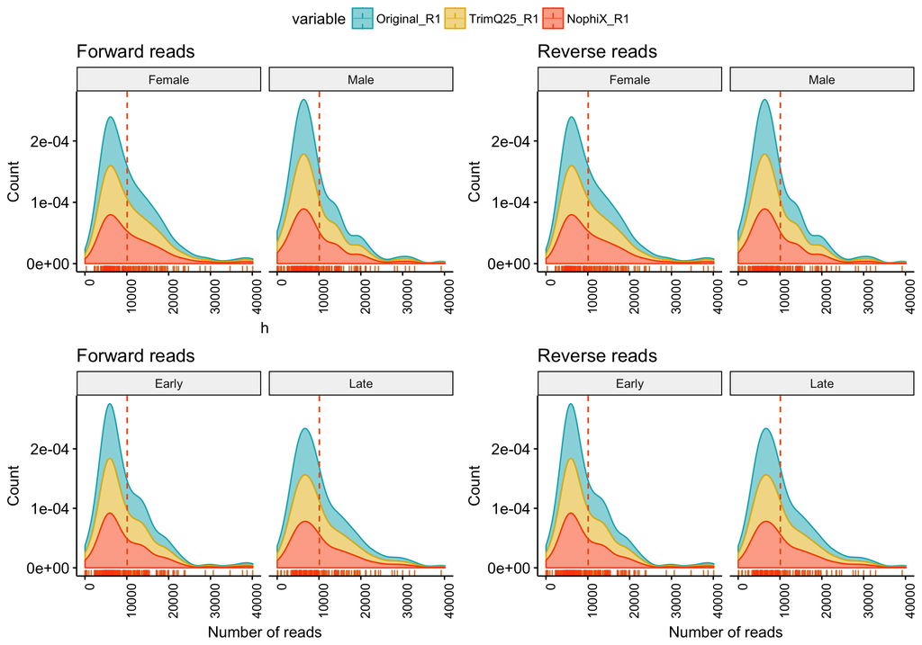

Figure x: Density plots of pre-processed read grouped by QC variables. Mean values are indicated by the dotted lines and marginal rugs are shown at the bottom.

## Histogram plots

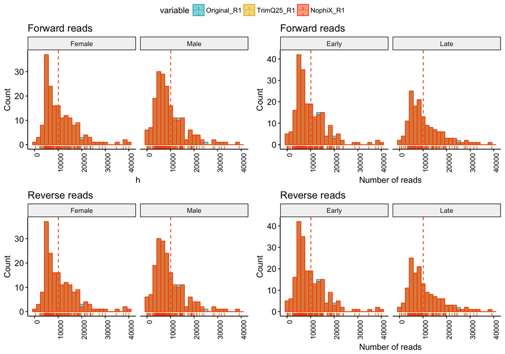

Figure x: Histogram plots of pre-processed read grouped by QC variables. Mean values are indicated by the dotted lines and marginal rugs are shown at the bottom.

# Summary of pre-processed reads

## Total read count

- Sum of all reads in all samples

```
Number of forward reads before QC (Original_R1):     3634461 ( 100 % )
```

```
Number of reverse reads before QC (Original_R2):     3634461 ( 100 % )
```

```
Number of forward reads after trimming at Q=25 (TrimQ25_R1):     3631940 ( 99.93064 % )
```

```
Number of reverse reads after trimming at Q=25 (TrimQ25_R2):     3631940 ( 99.93064 % )
```

```
Number of forward reads after phiX removal (NophiX_R1):  3631769 ( 99.92593 % )
```

```
Number of reverse reads after phiX removal (NophiX_R2):  3631769 ( 99.92593 % )
```

## Descriptive statistics

|  | Original_R1 | TrimQ25_R1 | NophiX_R1 | Original_R2 | TrimQ25_R2 | NophiX_R2 |
| --- | --- | --- | --- | --- | --- | --- |
|  | Min. : 14 | Min. : 14 | Min. : 14 | Min. : 14 | Min. : 14 | Min. : 14 |
|  | 1st Qu.: 5368 | 1st Qu.: 5365 | 1st Qu.: 5365 | 1st Qu.: 5368 | 1st Qu.: 5365 | 1st Qu.: 5365 |
|  | Median : 8001 | Median : 7996 | Median : 7996 | Median : 8001 | Median : 7996 | Median : 7996 |
|  | Mean :10096 | Mean :10089 | Mean :10088 | Mean :10096 | Mean :10089 | Mean :10088 |
|  | 3rd Qu.:13636 | 3rd Qu.:13630 | 3rd Qu.:13630 | 3rd Qu.:13636 | 3rd Qu.:13630 | 3rd Qu.:13630 |
|  | Max. :40113 | Max. :40077 | Max. :40077 | Max. :40113 | Max. :40077 | Max. :40077 |